# Acute Changes in CEWL as a Function of Temperature: HOBO Data Logger Summary

Savannah Weaver, Calvin Davis

2022

# Packages

```r
if (!require("tidyverse")) install.packages("tidyverse")
library("tidyverse")
if (!require("emmeans")) install.packages("emmeans")
library("emmeans")
if (!require("rmdformats")) install.packages("rmdformats")
library("rmdformats")
```

# Background

# Load in Data

This data was collected using Onset HOBO temperature and humidity dataloggers during the course of our heating/cooling CEWL experiments.

The data is in a separate file for each download for each logger, so I need to compile each of those into one dataset.

To do this, first I compile a list of the filenames I need to read-in.

## File Names

```r
# make a list of file names of all data to load in
filenames <- list.files(path = "Data/HOBO data", pattern = ".csv")
```

Next, I make a function that will read in the data from each csv, name and organize the data correctly.

## Function

```r
# make a function to read in data from each csv file and add correct identifiers
read_HOBO_files <- function(filename) {

  # edit the filename inputted to funtion
  # to make a unique identifier for each logger
  name <- substr(filename, 8, 15)
  # read in the csv file for this given filename
  dat <- read.csv(file.path("./Data/HOBO data", filename),
                # each csv has headers
                header = TRUE,
                # this is what I want to rename the col headers
                col.names = c("order", "date_time_PST", "temp_C",
                              "relative_humidity", "dew_pt_C",
                              # the 6,7,8th cols are not data
                              # logger use info we don't need
                              "mostly_blank", "mostly_blank", "mostly_blank")
                ) %>%
    # select only the cols with data we want
    # don't need order- just an arbitrary observation identifier
    # don't need "mostly_blank" cols- unnecessary logger use info
    # but get the rest of the cols with informative data
    dplyr::select(date_time_PST, temp_C, relative_humidity, dew_pt_C) %>%
    # add a column with the name of the HOBO the data is from
    dplyr::mutate(HOBO_serial_number = name)

  # return the dataframe for that single csv file
  dat
}
```

## Apply

Finally, I apply the function I made to all of the filenames I compiled, then put all of those dataframes into one dataframe for my analyses.

This will print warnings saying that header and col.names are different lengths, because the data has extra notes on logger usage that we read-in, but get rid of.

```r
# apply function to get data from all csvs
all_HOBO_data <- lapply(filenames, read_HOBO_files) %>%
  # paste all data files together into one df by row
  reduce(rbind) %>%
  mutate(date = as.Date(substr(date_time_PST, 1, 10), format = "%m/%d/%Y"),
         date_time_PST = as.POSIXct(date_time_PST,
                                    format = "%m/%d/%Y %H:%M:%S")) %>%
  # remove missing data
  dplyr::filter(complete.cases(date_time_PST, relative_humidity)) %>%
  mutate(HOBO_serial_number = str_trim(HOBO_serial_number), # remove trailing white space
         HOBO_serial_number = str_replace_all(HOBO_serial_number, "[^A-z0-9]", "_"), # replace any special characters with underscores
         HOBO_serial_number = as.factor(HOBO_serial_number), # set class as factor
         temp_C = as.numeric(temp_C),
         relative_humidity = as.numeric(relative_humidity),
         dew_pt_C = as.numeric(dew_pt_C)
         )
```

[output not shown]

[output cut: 16 more lines]

[output not shown]

```r
summary(all_HOBO_data)
```

```
##  date_time_PST                        temp_C      relative_humidity
##  Min.   :2021-10-05 11:00:00.00   Min.   :10.06   Min.   : 1.160
##  1st Qu.:2021-10-11 17:00:00.00   1st Qu.:13.75   1st Qu.: 6.978
##  Median :2021-10-18 16:00:00.00   Median :24.43   Median : 9.940
##  Mean   :2021-10-15 05:34:24.06   Mean   :25.13   Mean   :17.702
##  3rd Qu.:2021-10-19 06:00:00.00   3rd Qu.:37.52   3rd Qu.:30.902
##  Max.   :2021-10-19 19:30:00.00   Max.   :38.77   Max.   :51.380
##     dew_pt_C       HOBO_serial_number      date
##  Min.   :-39.520   20785309:112       Min.   :2021-10-05
##  1st Qu.:-19.453   20785311:110       1st Qu.:2021-10-11
##  Median : -1.655   20785317:112       Median :2021-10-18
##  Mean   : -4.947   20793609:110       Mean   :2021-10-14
##  3rd Qu.:  6.463   20932041:112       3rd Qu.:2021-10-19
##  Max.   : 14.650   20932042:112       Max.   :2021-10-19
```

```r
head(all_HOBO_data)
```

```
##         date_time_PST temp_C relative_humidity dew_pt_C HOBO_serial_number
## 1 2021-10-05 11:00:00  14.29              8.16   -19.29           20785309
## 2 2021-10-05 11:30:00  14.89              5.62   -23.10           20785309
## 3 2021-10-05 12:00:00  14.52              4.59   -25.61           20785309
## 4 2021-10-05 12:30:00  14.66              5.21   -24.12           20785309
## 5 2021-10-05 13:00:00  14.78              4.52   -25.61           20785309
## 6 2021-10-05 13:30:00  15.72             15.13   -10.72           20785309
##         date
## 1 2021-10-05
## 2 2021-10-05
## 3 2021-10-05
## 4 2021-10-05
## 5 2021-10-05
## 6 2021-10-05
```

## Check Data

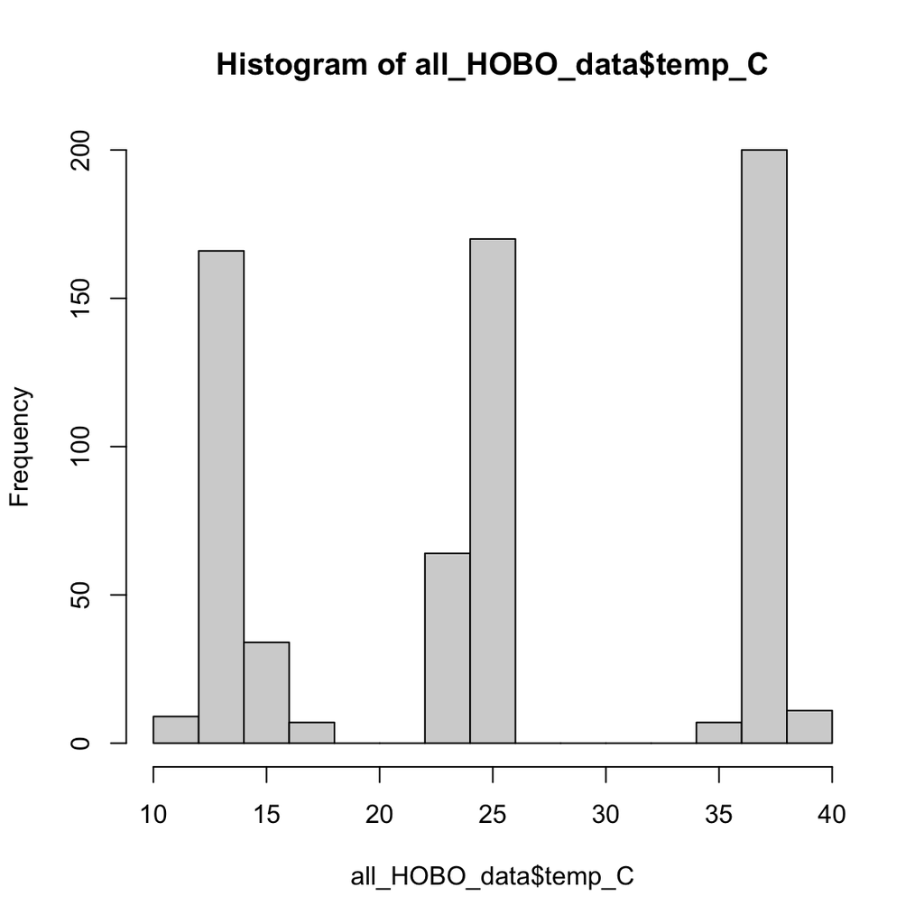

```r
hist(all_HOBO_data$temp_C)
```

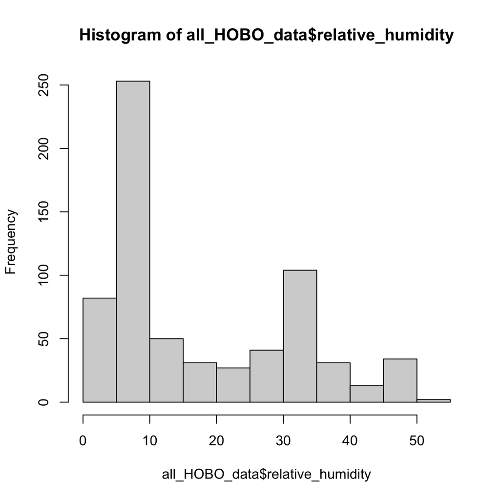

```r
hist(all_HOBO_data$relative_humidity)
```

How many observations are there for a given logger serial at a given datetime? This should only be one.

```r
all_HOBO_data %>%
  group_by(HOBO_serial_number, date_time_PST) %>%
  dplyr::summarise(n = n()) %>%
  arrange(n)
```

```
## # A tibble: 668 × 3
## # Groups:   HOBO_serial_number [6]
##    HOBO_serial_number date_time_PST           n
##    <fct>              <dttm>              <int>
##  1 20785309           2021-10-05 11:00:00     1
##  2 20785309           2021-10-05 11:30:00     1
##  3 20785309           2021-10-05 12:00:00     1
##  4 20785309           2021-10-05 12:30:00     1
##  5 20785309           2021-10-05 13:00:00     1
##  6 20785309           2021-10-05 13:30:00     1
##  7 20785309           2021-10-05 14:00:00     1
##  8 20785309           2021-10-05 14:30:00     1
##  9 20785309           2021-10-05 15:00:00     1
## 10 20785309           2021-10-05 15:30:00     1
## # … with 658 more rows
```

Good, no duplicate data.

## Attach Treatment Info

```r
# load HOBO assignment data
HOBO_tmts <- read.csv("./Data/HOBO_assignments.csv") %>%
           mutate(date = as.Date(date, format = "%d/%m/%Y"),
                  treatment = as.factor(treatment),
                  HOBO_serial_number = str_trim(serial),
                  HOBO_serial_number = str_replace_all(HOBO_serial_number,
                                              "[^A-z0-9]", "_"),
                  HOBO_serial_number = as.factor(HOBO_serial_number))
# combine & summarize again
format_HOBO_data <- all_HOBO_data %>%
  left_join(HOBO_tmts, by = c("date", "HOBO_serial_number")) %>%
  dplyr::select(-serial, -trial)
summary(format_HOBO_data)
```

```
##  date_time_PST                        temp_C      relative_humidity
##  Min.   :2021-10-05 11:00:00.00   Min.   :10.06   Min.   : 1.160
##  1st Qu.:2021-10-11 17:00:00.00   1st Qu.:13.75   1st Qu.: 6.978
##  Median :2021-10-18 16:00:00.00   Median :24.43   Median : 9.940
##  Mean   :2021-10-15 05:34:24.06   Mean   :25.13   Mean   :17.702
##  3rd Qu.:2021-10-19 06:00:00.00   3rd Qu.:37.52   3rd Qu.:30.902
##  Max.   :2021-10-19 19:30:00.00   Max.   :38.77   Max.   :51.380
##     dew_pt_C       HOBO_serial_number      date              treatment
##  Min.   :-39.520   20785309:112       Min.   :2021-10-05   cold   :222
##  1st Qu.:-19.453   20785311:110       1st Qu.:2021-10-11   control:222
##  Median : -1.655   20785317:112       Median :2021-10-18   hot    :224
##  Mean   : -4.947   20793609:110       Mean   :2021-10-14
##  3rd Qu.:  6.463   20932041:112       3rd Qu.:2021-10-19
##  Max.   : 14.650   20932042:112       Max.   :2021-10-19
```

Dates there is data for each tmt:

```r
format_HOBO_data %>%
  group_by(date, treatment) %>%
  summarise(n = n())
```

```
## # A tibble: 15 × 3
## # Groups:   date [5]
##    date       treatment     n
##    <date>     <fct>     <int>
##  1 2021-10-05 cold         32
##  2 2021-10-05 control      32
##  3 2021-10-05 hot          32
##  4 2021-10-11 cold         30
##  5 2021-10-11 control      30
##  6 2021-10-11 hot          32
##  7 2021-10-12 cold         32
##  8 2021-10-12 control      32
##  9 2021-10-12 hot          32
## 10 2021-10-18 cold         48
## 11 2021-10-18 control      48
## 12 2021-10-18 hot          48
## 13 2021-10-19 cold         80
## 14 2021-10-19 control      80
## 15 2021-10-19 hot          80
```

We have data for all (incubation) treatment groups on these dates: October 5, 11, 12, 18, and 19 This is correct! (See data analysis line 52, in the first code chunk.)

How many loggers were used on a given date for a given tmt group?

```r
format_HOBO_data %>%
  # first, aggregate for each hobo
  group_by(HOBO_serial_number, date, treatment) %>%
  summarise(n = n()) %>%
  # then group hobos
  group_by(date, treatment) %>%
  summarise(n = n())
```

```
## # A tibble: 15 × 3
## # Groups:   date [5]
##    date       treatment     n
##    <date>     <fct>     <int>
##  1 2021-10-05 cold          2
##  2 2021-10-05 control       2
##  3 2021-10-05 hot           2
##  4 2021-10-11 cold          2
##  5 2021-10-11 control       2
##  6 2021-10-11 hot           2
##  7 2021-10-12 cold          2
##  8 2021-10-12 control       2
##  9 2021-10-12 hot           2
## 10 2021-10-18 cold          2
## 11 2021-10-18 control       2
## 12 2021-10-18 hot           2
## 13 2021-10-19 cold          2
## 14 2021-10-19 control       2
## 15 2021-10-19 hot           2
```

2 loggers per tmt per date, as expected.

# Statistics

## Logger Means

```r
logger_means <- format_HOBO_data %>%
  group_by(date, treatment, HOBO_serial_number) %>%
  summarise(temp_mean = mean(temp_C),
            temp_SD = sd(temp_C),
            humidity_mean = mean(relative_humidity),
            humidity_SD = sd(relative_humidity)) %>%
  arrange(treatment)
logger_means
```

```
## # A tibble: 30 × 7
## # Groups:   date, treatment [15]
##    date       treatment HOBO_serial_number temp_mean temp_SD humidity_…¹ humid…²
##    <date>     <fct>     <fct>                  <dbl>   <dbl>       <dbl>   <dbl>
##  1 2021-10-05 cold      20785309                16.9   3.92        19.3    20.0
##  2 2021-10-05 cold      20785311                16.7   4.23        19.6    20.1
##  3 2021-10-11 cold      20793609                12.6   0.943       11.3     4.84
##  4 2021-10-11 cold      20932042                13.1   1.04        10.3     4.58
##  5 2021-10-12 cold      20793609                13.3   0.835        9.75    8.01
##  6 2021-10-12 cold      20932042                13.1   0.815        9.57    8.18
##  7 2021-10-18 cold      20785317                13.8   0.758        8.67    8.41
##  8 2021-10-18 cold      20932041                12.8   0.755        9.35    9.02
##  9 2021-10-19 cold      20785317                13.7   0.727        4.82    4.32
## 10 2021-10-19 cold      20932041                12.5   0.466        5.35    4.48
## # … with 20 more rows, and abbreviated variable names ¹humidity_mean,
## #   ²humidity_SD
```

## Treatment Means + VPD

**These values are for the primary temperature treatment in the incubation chambers, before the CEWL time series measurements.**

```r
tmt_means <- format_HOBO_data %>%
  # calculate VPD for ALL temp/RH, based on Campbell & Normal 1998
  mutate(e_s_kPa = 0.611 * exp((17.502*temp_C)/(temp_C + 240.97)),
         VPD_kPa = e_s_kPa*(1 - (relative_humidity/100))) %>%
  group_by(treatment) %>%
  summarise(temp_mean = mean(temp_C),
            temp_SD = sd(temp_C),
            humidity_mean = mean(relative_humidity),
            humidity_SD = sd(relative_humidity),
            VPD_mean = mean(VPD_kPa),
            VPD_sd = sd(VPD_kPa))
tmt_means
```

```
## # A tibble: 3 × 7
##   treatment temp_mean temp_SD humidity_mean humidity_SD VPD_mean VPD_sd
##   <fct>         <dbl>   <dbl>         <dbl>       <dbl>    <dbl>  <dbl>
## 1 cold           13.7   2.15           9.43       10.5      1.41  0.144
## 2 control        24.4   0.500         32.9         6.97     2.04  0.187
## 3 hot            37.3   2.03          10.8         7.16     5.74  0.748
```

```r
write.csv(tmt_means, "./Results_Statistics/HOBO_climate_means_by_treatment.csv")
```

## Date Differences during Measurement period

We want to know what the VPD was in the lab while we took CEWL measurements, and whether it was different across dates.

```r
# get the data we want to compare
date_diffs <- format_HOBO_data %>%
  dplyr::filter(treatment == "control") %>%
  # calculate VPD, based on Campbell & Normal 1998
  mutate(e_s_kPa = 0.611 * exp((17.502*temp_C)/(temp_C + 240.97)),
         VPD_kPa = e_s_kPa*(1 - (relative_humidity/100)),
         date = as.factor(date))

# statistically compare
date_diffs_lm <- lm(data = date_diffs, VPD_kPa ~ date)
emmeans <- data.frame(emmeans(date_diffs_lm, "date"))
emmeans
```

```
##         date   emmean         SE  df lower.CL upper.CL
## 1 2021-10-05 1.720732 0.01847458 217 1.684320 1.757145
## 2 2021-10-11 2.125254 0.01908046 217 2.087647 2.162860
## 3 2021-10-12 2.272688 0.01847458 217 2.236276 2.309101
## 4 2021-10-18 2.002569 0.01508443 217 1.972838 2.032300
## 5 2021-10-19 2.069215 0.01168435 217 2.046186 2.092244
```

```r
emmean_ps <- data.frame(pairs(emmeans(date_diffs_lm, "date"))) # p values
emmean_ps
```

```
##                       contrast    estimate         SE  df    t.ratio
## 1  (2021-10-05) - (2021-10-11) -0.40452127 0.02655888 217 -15.231113
## 2  (2021-10-05) - (2021-10-12) -0.55195585 0.02612700 217 -21.125882
## 3  (2021-10-05) - (2021-10-18) -0.28183661 0.02385058 217 -11.816763
## 4  (2021-10-05) - (2021-10-19) -0.34848286 0.02185941 217 -15.942004
## 5  (2021-10-11) - (2021-10-12) -0.14743458 0.02655888 217  -5.551235
## 6  (2021-10-11) - (2021-10-18)  0.12268467 0.02432291 217   5.043996
## 7  (2021-10-11) - (2021-10-19)  0.05603841 0.02237382 217   2.504642
## 8  (2021-10-12) - (2021-10-18)  0.27011925 0.02385058 217  11.325481
## 9  (2021-10-12) - (2021-10-19)  0.20347299 0.02185941 217   9.308255
## 10 (2021-10-18) - (2021-10-19) -0.06664626 0.01908046 217  -3.492906
##         p.value
## 1  0.000000e+00
## 2  0.000000e+00
## 3  0.000000e+00
## 4  0.000000e+00
## 5  8.180454e-07
## 6  9.486051e-06
## 7  9.333951e-02
## 8  0.000000e+00
## 9  0.000000e+00
## 10 5.195377e-03
```

Based on these brief and rough calculations, there are differences across dates, but that’s also because we have a lot of data. So, even though the effect size differences are small (range of mean VPDs < 0.6 kPa), a significant difference is detected probably because we just have to many data points.

## Models

Run linear models with pairwise post-hoc tests to determine when and how much climate varied among treatments and dates.

```r
# temperature
temp_mod <- lm(data = format_HOBO_data,
               temp_C ~ treatment * as.factor(date))
a_temp_mod <- aov(temp_mod)
ph_temp_mod <- TukeyHSD(a_temp_mod)
temp_mod_df <- data.frame(broom::tidy(ph_temp_mod)) %>%
  arrange(desc(adj.p.value))
write.csv(temp_mod_df, "./Results_Statistics/HOBO_temp_pairwise_diffs.csv")

# humidity
humidity_mod <- lm(data = format_HOBO_data,
                   relative_humidity ~ treatment * as.factor(date))
a_humid_mod <- aov(humidity_mod)
ph_humid_mod <- TukeyHSD(a_humid_mod)
humid_mod_df <- data.frame(broom::tidy(ph_humid_mod)) %>%
  arrange(desc(adj.p.value))
write.csv(humid_mod_df,
          "./Results_Statistics/HOBO_humidity_pairwise_diffs.csv")
```

## Boxplots

Simple plots looking at the distribution of temperature and humidity for each treatment group:

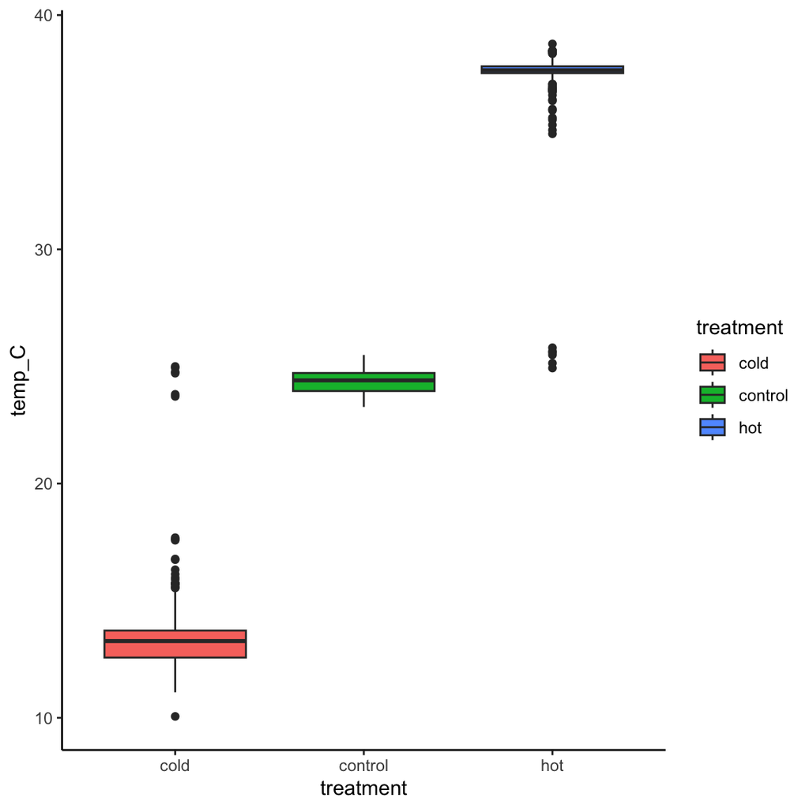

```r
ggplot(format_HOBO_data) +
  geom_boxplot(aes(x = treatment,
                   y = temp_C,
                   fill = treatment)) +
  theme_classic()
```

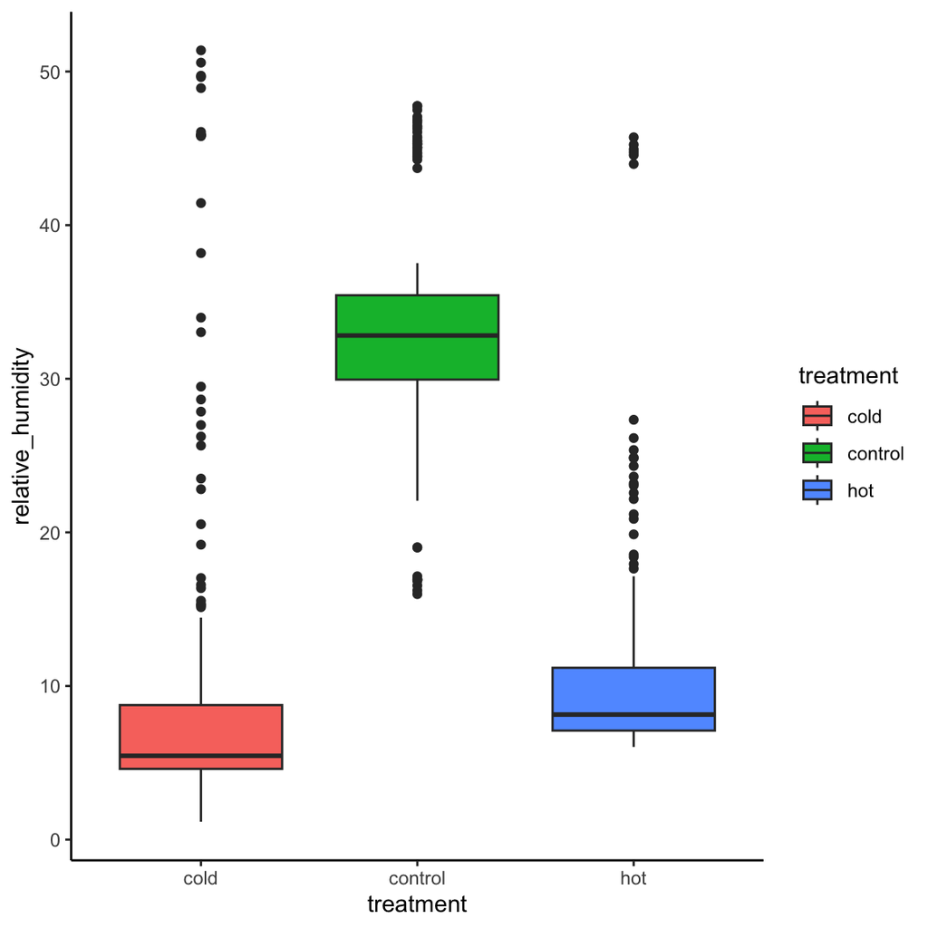

```r
ggplot(format_HOBO_data) +
  geom_boxplot(aes(x = treatment,
                   y = relative_humidity,
                   fill = treatment)) +
  theme_classic()
```

and by treatment group * date:

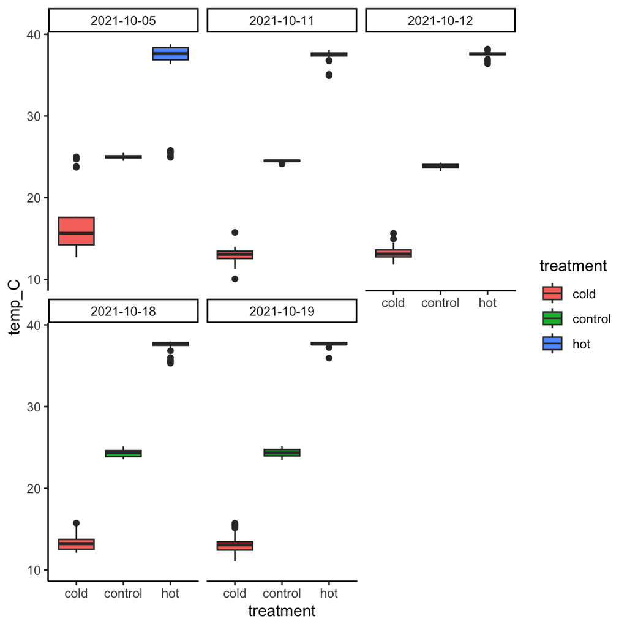

```r
ggplot(format_HOBO_data) +
  geom_boxplot(aes(x = treatment,
                   y = temp_C,
                   fill = treatment)) +
  theme_classic() +
  facet_wrap(~date)
```

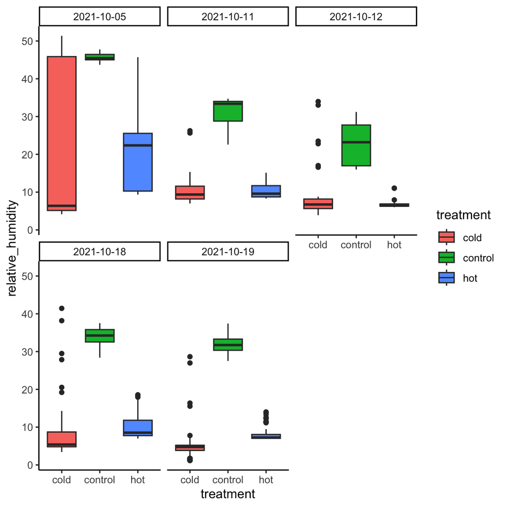

```r
ggplot(format_HOBO_data) +
  geom_boxplot(aes(x = treatment,
                   y = relative_humidity,
                   fill = treatment)) +
  theme_classic()+
  facet_wrap(~date)
```

# For the Paper

## Re-Print

```r
# tmt means calculated with arithmetic (vs models)
tmt_means
```

```
## # A tibble: 3 × 7
##   treatment temp_mean temp_SD humidity_mean humidity_SD VPD_mean VPD_sd
##   <fct>         <dbl>   <dbl>         <dbl>       <dbl>    <dbl>  <dbl>
## 1 cold           13.7   2.15           9.43       10.5      1.41  0.144
## 2 control        24.4   0.500         32.9         6.97     2.04  0.187
## 3 hot            37.3   2.03          10.8         7.16     5.74  0.748
```

```r
# average temperatures by treatment
coefficients(temp_mod)[1:3]
```

```
##      (Intercept) treatmentcontrol     treatmenthot
##         16.79688          8.21000         18.68375
```

```r
# statistical differences in temp by tmt
temp_mod_df %>% dplyr::filter(term == "treatment")
```

```
##        term     contrast null.value estimate conf.low conf.high adj.p.value
## 1 treatment control-cold          0 10.70081 10.36537  11.03625           0
## 2 treatment     hot-cold          0 23.58663 23.25194  23.92132           0
## 3 treatment  hot-control          0 12.88582 12.55113  13.22051           0
```

```r
# average humidity by treatment
coefficients(humidity_mod)[1:3]
```

```
##      (Intercept) treatmentcontrol     treatmenthot
##        19.468750        26.213437         3.029063
```

```r
# statistical differences in humidity by tmt
humid_mod_df %>% dplyr::filter(term == "treatment")
```

```
##        term     contrast null.value  estimate     conf.low conf.high
## 1 treatment     hot-cold          0   1.35601  -0.09384014   2.80586
## 2 treatment control-cold          0  23.51703  22.06392984  24.97012
## 3 treatment  hot-control          0 -22.16102 -23.61086717 -20.71117
##   adj.p.value
## 1   0.0724189
## 2   0.0000000
## 3   0.0000000
```

```r
tmt_means
```

```
## # A tibble: 3 × 7
##   treatment temp_mean temp_SD humidity_mean humidity_SD VPD_mean VPD_sd
##   <fct>         <dbl>   <dbl>         <dbl>       <dbl>    <dbl>  <dbl>
## 1 cold           13.7   2.15           9.43       10.5      1.41  0.144
## 2 control        24.4   0.500         32.9         6.97     2.04  0.187
## 3 hot            37.3   2.03          10.8         7.16     5.74  0.748
```

## Statement

We maintained temperatures of 13.7 +/- 2.1 for the cold primary temperature treatment, 24.4 +/- 0.5 for control, and 37.3 +/- 2.0 for hot. However, relative humidity was not consistent among primary incubation temperature treatments (33% for control but only 9% and 11% for cold and hot, respectively), a difference that was significantly different in a Tukey HSD ANOVA post-hoc test. VPD during the primary incubation temperature treatments was ~1.4 for the cold treatment, ~2.0 for control, and ~5.7 for hot.